# Dcard成大版分析

# 簡介

Dcard為目前台灣大學生常用的社群APP之一，有許多各式各樣的論壇版，其中成功大學又常被稱為「廢文大學」，喜歡PO一些無聊、沒意義的文章，又常戰系、戰學校，但事情真的是如此嗎?

這次的資料分析想要透過研究Dcard的成大版，從2019/07/19的最後一篇文章，回推取100篇Dcard文章來分析，從這些文章可以深入研究，討論成大版最常討論的詞彙或者什麼人比較常PO文等等問題，進而回復「成大是否為廢文大學?」。

===

1.先將需要的library載入

```r
# load the library
#爬蟲使用
library(httr)
library(jsonlite)
#文字整理
library(tm)
#斷詞
library(jiebaRD)
library(jiebaR)
#資料切割、篩選
library(dplyr)
#畫圖
library(ggplot2)
#文字雲
library(wordcloud)
```

2.預設字串不要轉成factor、讀檔用UTF-8

```r
options(stringsAsFactors = FALSE)
options(encoding = "UTF-8")
```

3.自訂三個function：

(1)用於取得每篇文章的內文 (2)用於取得每篇文章的留言 (3)用於中文斷詞,且每個詞數至少需要大於1

```r
#get the Dcard post(input: url & Dcard id )
getcontent<-function(dcardurl,id){
  mainurl<- paste0(dcardurl,id,collapse="")
  resdata<- jsonlite::fromJSON(httr::content(GET(mainurl),"text",encoding = "UTF-8"))
  toString(resdata$content)
}
#get all the comment in each post(input: url & Dcard id )
getcomment<-function(dcardurl,id){
  mainurl<- paste0(dcardurl,id,'/comments?limit=50',collapse="")
  json<-httr::content(GET(mainurl), "text",encoding = "UTF-8")
  resdata<- jsonlite::fromJSON(json)
  toString(resdata$content)
}
# get the chinese word
myFUN<- function(str,term) {
  str = gsub("[A-Za-z0-9]", "", str)
  seg = cutter[str]
  seg = seg[names(seg)==term]
  id = which(nchar(seg) > 1)
  result = seg[id]
}
```

4.爬蟲100文章的基本資料，例如：用戶id、學校名稱、科系、讚數、留言數等等(除了文章內容以及每篇文章的留言內容)

```r
dcardurl <- 'https://www.dcard.tw/_api/forums/ncku/'
mainurl <- paste0(dcardurl,'posts?popular=false&limit=100&before=231705029')
resdata<- fromJSON(httr::content(GET(mainurl), 'text'))
```

5.利用function求出內文跟留言內容，並併入resdata裡

```r
content<-unlist(lapply(resdata$id,getcontent,dcardurl='https://www.dcard.tw/_api/posts/'))
comment<-unlist(lapply(resdata$id,getcomment,dcardurl='https://www.dcard.tw/_api/posts/'))

Dcard<-data.frame(resdata$id,resdata$title,resdata$createdAt,
                  resdata$updatedAt,resdata$department,
                  resdata$commentCount,resdata$likeCount,
                  resdata$gender,content,comment)
head(Dcard$content)
```

```
## [1] "想問問這裡有沒有人是住在「成大學苑 No.2」 的人\n如果想叫 foodpanda 或是達美樂 之類的外送可以嗎？\n是直接送到我住的房號門前還是會被擋在宿舍門口\n\n請有經驗者幫我解答一下～～"
## [2] "請問成大附近有學開小汽車的駕校嗎？謝謝"
## [3] "大家能說一下申請科系各組排隊到的編號嗎 這樣大概就知道申請幾個人了\n聽說今年超多人的qqq"
## [4] "嗚嗚嗚嗚嗚台南下大雨\n想問問地停的情況QQ"
## [5] "想請問一下板眾\n記得在幾年前\n在現在牟王牛排的那個位置附近\n有一間賣鐵板便當的\n店名不太記得了\n開店的是一堆夫妻\n以前大學的時候很常吃\n現在回去看的時候已經不見了\n有人知道是搬去哪裡了嗎\n還是說結束營業了\n感謝"
## [6] "出生到現在20年還沒淹過水\n莫拉克沒淹 823沒淹 感謝韓導高雄發大財\n20年沒淹的建工路淹水 賭爛到極致 \n害我清水清到一直飆髒話🤬"
```

```r
head(Dcard$comment)
```

```
## [1] "送到你嘴巴前\n我也ok的, 外面的人, 可以進入你的住處( 成大學苑 No.2 )的範圍?!, B0也太懶了吧😂😂😂, 建議不要 \n送到管理室或外面去拿比較好, B3 因為不知道附近有什麼好吃的😂😂, B4 你是說在備註裡面寫說在騎樓拿嗎？, 寫送到一樓打電話就好, https://i.imgur.com/Igyqy6z.jpg\n安內, B8 B7 謝謝你們～"
## [2] "第一次看到這種簡稱，我以為都叫駕訓班, 伸手牌? 還好顏色正確, 我送你就好了，何必學車呢, https://i.imgur.com/Rd5PsWo.jpg, 我載你就好, 非本土才跟你駕校, 有一個會幫你踩煞車的，是哪個我不能說, 你可以搭火車到永康火車站，站前面步行1分鐘就有駕訓班ㄌ而且賊便宜, 最低學費就 8000喔 不含考試1600, B9 想請問這是哪一間？今年有漲過駕訓班學費？, 崑山\n\n\n政府有說要把最低費用改成 1w\n但上個月的時候還是8k"
## [3] "在這邊窮緊張到底是有什麼用喇, 沒轉上重考發現人生新大陸, 等等\n他那個編號是指一個系收件數\n還是一整個櫃台啊？, B3 估計就是他那個櫃台吧.., 櫃檯吧\n所以也不太能估計, B5 可以吧\n每個櫃台負責科系不一樣, 一個櫃檯負責很多系 我是直接問承辦人有多少人申請, B7 那你是申請哪個的 有到幾號, B8編號跟人數差很多, B9 是什麼意思  不是就看你是第幾個收件嗎, B10很多系混在一起 可能你編號十號卻是唯一一個申請的, B11 哦懂了謝謝你🙏🙏\n      那今年有哪些科系是爆多人的, B12 這我不知道欸, 4號櫃檯只有負責電機系，有4號櫃檯的消息嗎, …
## [4] "我覺得沒大到會淹的程度\n你停在哪邊？, B1 我只知道妳停在我心裡, 別怕 這裡不是高雄, 我在成大大學+研究所=7年\n光復地停沒有淹水過\n你覺得現在的情況會如何?!\np/s: 學校颱風/暴雨後蠻多地方會淹水, 但就光復地停沒有看過淹水, 台南沒有韓流, 發大財, 去年823也只有勝後淹水而已啊\n安啦"
## [5] "牛車伯QQ？, 記得那家口味滿重的XD\n應該就結束營業了, 牛車伯已經倒了, 牛車伯還是牛伯車忘記哪一個是正確ㄉ，是在我高三的時候關的，現在大四, B4 黑白講 我大一進來之後關的 現在大四 還是你跳級？, 牛車伯嗚嗚嗚嗚嗚嗚嗚嗚, B5 哦對我有提升編級抱歉ˊˋ....., 我都吃羊肉小辣一定要加一顆半熟蛋, 有種挑戰大辣中辣的都是真男人, 印象是搬去台北?, 去台北了 在哪開我就不知道了 可能也退休了, 那時候問牛車伯的老闆，他說是要照顧小孩所以就結束營業了QQ\n\n---- 每次都吃大辣的男人, 牛車伯明明沒很好吃==, 育樂街都是噴"
## [6] "我高雄住了21年\n每年都淹水\n\n你這不是反串就是傻逼, B1 你看看建工路 我家這邊可是20年沒淹過水\n你大概是住高雄縣吧, 最好是花媽的時候沒淹水\n1450下去, B3 20年沒淹ok? 媽的 賭爛到極致 一直想飆髒話, 惱羞了 怕爆, 九如路以前也沒淹過, B6 看到上面那幾個讓我更火大 \n這樣還可以護航B3\n真的傻眼🙄, 我第一次看到高雄鳳山行政中心淹水淹這麼多了，去年都沒這麼恐怖, 人家他們家就會淹啊\n你傻眼個毛線 你家排水系統比較優秀不就好棒, B8 我好奇他到底做了什麼🤔\n韓國瑜趕快給我出來解釋, B9 我針對B3, 你要不要看一小時下多少啊\n你…
```

6.斷詞設定器，並取得文字的詞性，和加入新詞彙「成大」。

**註**write = “NOFILE”用於防止讀檔的問題

```r
#set the cutter
cutter <- worker('tag',write = "NOFILE")
new_user_word(cutter,'成大','n')
```

```
## [1] TRUE
```

```r
new_user_word(cutter,'韓國瑜','n')
```

```
## [1] TRUE
```

```r
new_user_word(cutter,'韓粉','n')
```

```
## [1] TRUE
```

```r
new_user_word(cutter,'蔡英文','n')
```

```
## [1] TRUE
```

```r
new_user_word(cutter,'甲甲','n')
```

```
## [1] TRUE
```

```r
new_user_word(cutter,'民進黨','n')
```

```
## [1] TRUE
```

7.套用function，將所有內文斷詞，並做次數累積

```r
#cut the post
txt1<-unlist(lapply(Dcard$content[1:100],myFUN,'n'))
st1<-freq(txt1)
st1<-st1[order(st1$freq,decreasing = TRUE),]
```

8.文字雲

內文的文字雲

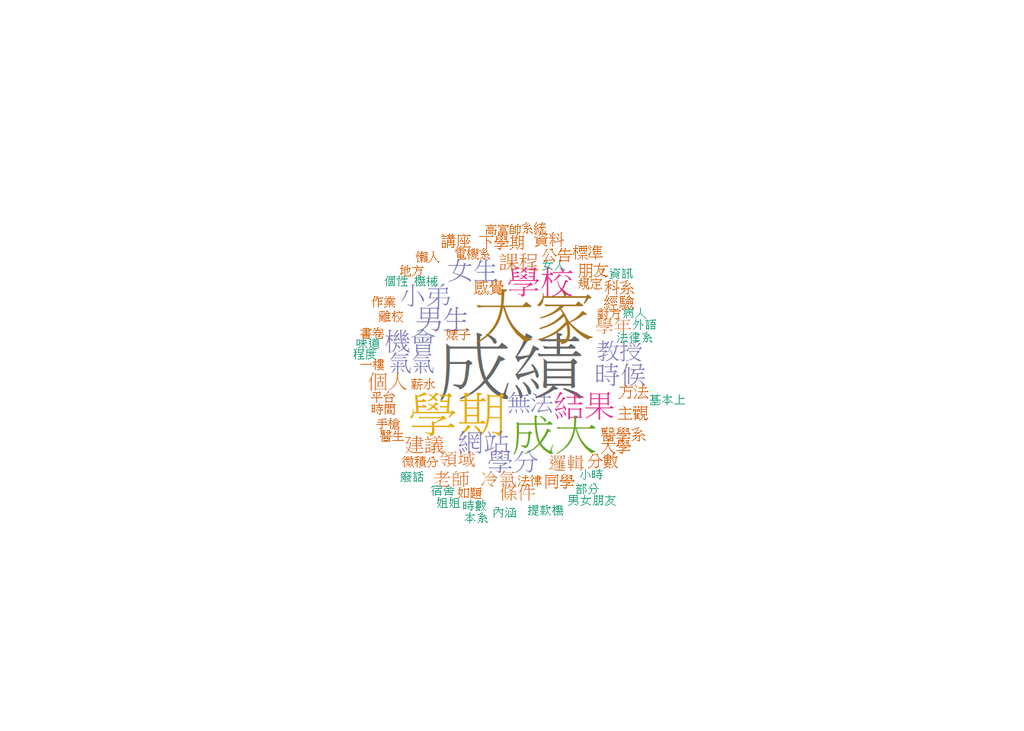

```r
wordcloud(words=st1$char,freq=st1$freq,scale = c(3,0.1), # 給定文字尺寸的區間（向量）
          random.order = F,# 關閉文字隨機顯示 按順序
          ordered.colors = F,#關閉配色順序
          rot.per = F,#關閉文字轉角度
          min.freq = 3,# 定義最小freq數字
          colors = brewer.pal(8,"Dark2")
)
```

9.結論

從文字雲可以看出，在7/15-7/19這幾天中，主要都討論「選課、轉系資訊有關」，像是成績、學分、科系、書卷、條件或是機會，都是跟轉系有關，其中可以看出「法律系」、「電機系」以及「醫學系」討論熱烈，另外，還可以發現有一個小主題，談論到女生的部分蠻多的，像是女生、條件、高富帥、婊子或女人，看來成大學生在Dcard上蠻常討論女生的，不管是女生喜歡男生的樣子，或是形容女生，看來真的是肥宅學校XD(有點小小仇女)